# Exam 1

## Exam 1

#### Metainformation

1. | Tag | Value |
   | --- | --- |
   | `file` | Inferential_Statistics_vufsw-onewayanova-1287-en_vufsw-onewayanova-1287-en |
   | `name` | vufsw-onewayanova-1287-en |
   | `section` | inferential statistics/parametric techniques/anova/oneway anova |
   | `type` | schoice |
   | `solution` | FALSE, FALSE, FALSE, TRUE |
   | `ID` | de6b3 |
   | `Type` | interpreting output |
   | `Program` | spss |
   | `Language` | English |
   | `Level` | statistical literacy |

#### Question

   In a study by Communication Studies students (Van Dun, Emanuels, Visser and De Wilde, 2011), respondents were presented with a picture of a girl who was dressed preppy, bohemian or cool (variable: subculture, 1 preppy; 2 bohemian; 3 cool (‘cool’)). Respondents, randomly assigned to the three conditions, had to rate the popularity of the girl. The dependent variable is popularity in terms of ‘social preference’ with items such as “With this girl ….”I would like to hang out with,” and …. “would I want to be friends with” (variable: sp, scale 1-5, a higher score means the girl is more popular). The hypothesis is that clothing style leads to different ratings of the girl’s popularity. Below are some results of an ANOVA.

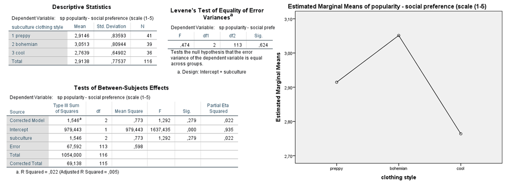

   What statement can you make based on the hypothesis testing about the population?  
   1: It is plausible that the average popularity attributed to the girl attributed differs among the three clothing styles 2: A bohemian clothing style is attributed a higher popularity attributed than to the other two clothing styles, preppy and cool (cool)
   1. **FALSE:** Only statement 1
   2. **FALSE:** Only pronunciation 2
   3. **FALSE:** Both statements
   4. **TRUE:** Neither statement
   1. False
   2. False
   3. False
   4. True